# STAT270 - Project 3 - Modeling with Regression

Brittany Smith

2026-04-02

```r
# load the packages for graphing and data wrangling
library(ggplot2)
library(PASWR2)
library(car) # install the car package first, if not already installed
library(dplyr)
library(lattice)
library(boot)
library(MASS)
```

**Note:** If you `Rmd` file submission knits you will receive total of **(5 points)**

## Case Study: Real Estate

Data and ideas for this case study come from (*Militino et al., 2004*).

**Problem 16, page 899** (**not entire problem**, only specified parts below)

The goal of this case study is to walk the user through the creation of a parsimonious multiple linear regression model that can be used to predict the total price (totalprice) of apartments by their hedonic (structural) characteristics. The data frame `VIT2005` contains several variables, and further description of the data can be found in the help file (listed below).

A data frame with 218 observations on the following 15 variables:

- `totalprice` (the market total price (in Euros) of the apartment including garage(s) and storage room(s))
- `area` (the total living area of the apartment in square meters)
- `zone` (a factor indicating the neighborhood where the apartment is located with levels `Z11, Z21, Z31, Z32, Z34, Z35, Z36, Z37, Z38, Z41, Z42, Z43, Z44, Z45, Z46, Z47, Z48, Z49, Z52, Z53, Z56, Z61, and Z62`)
- `category` (a factor indicating the condition of the apartment with levels `2A, 2B, 3A, 3B, 4A, 4B`, and `5A` ordered so that `2A` is the best and `5A` is the worst)
- `age` (age of the apartment in years)
- `floor` (floor on which the apartment is located)
- `rooms` (total number of rooms including bedrooms, dining room, and kitchen)
- `out` (a factor indicating the percent of the apartment exposed to the elements: The levels `E100, E75, E50, and E25`, correspond to complete exposure, `75`% exposure, `50`% exposure, and `25`% exposure, respectively.)
- `conservation` (is an ordered factor indicating the state of conservation of the apartment. The levels `1A, 2A, 2B, and 3A` are ordered from best to worst conservation.)
- `toilets` (the number of bathrooms)
- `garage` (the number of garages)
- `elevator` (indicates the absence (0) or presence (1) of elevators.)
- `streetcategory` (an ordered factor from best to worst indicating the category of the street with levels `S2, S3, S4, and S5`)
- `heating` (a factor indicating the type of heating with levels `1A, 3A, 3B, and 4A` which correspond to: no heating, low-standard private heating, high-standard private heating, and central heating, respectively.)
- `storage` (the number of storage rooms outside of the apartment)

### Complete the parts below

**(10 pts)** **Quiz-Project 3 Pr.1**

1. Characterize the shape, center, and spread of the variable `totalprice`.

Hint: Use `ggplot` function from `ggplot2` package to graph the `totalprice` density function. Use `median` and `IQR` to find the median and IQR for the `totalprice`. Fill in the blank spaces in the observation below:

**Solution:** Hint: Use the template for the graph:

`ggplot(data = YOUR DATA, aes(x = variable to plot)) + geom_density(fill = "your favorite color") + theme_bw()`

YOUR CODE HERE:

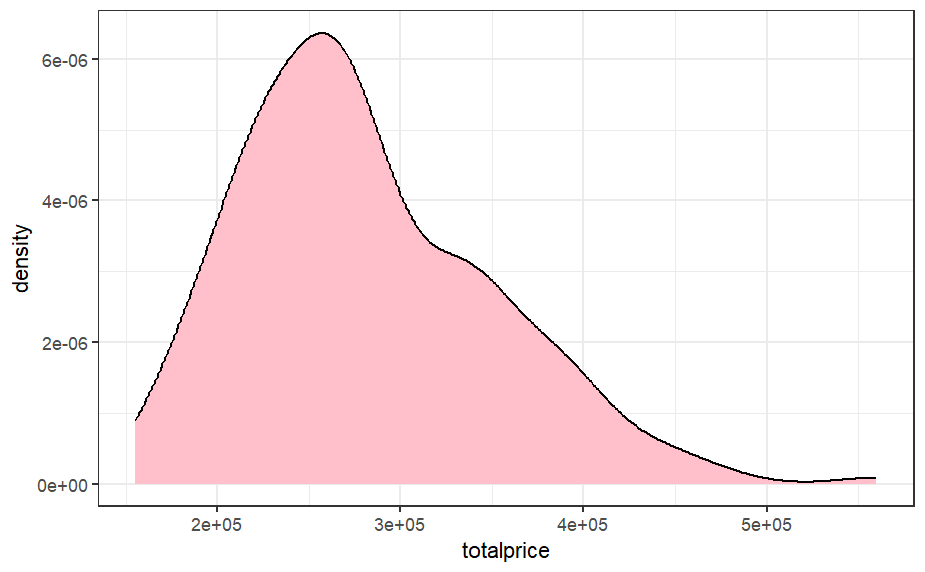

```r
# (1) graph the density of totalprice and (2) compute the median and IQR.
ggplot(data = VIT2005, aes(x = totalprice)) +  geom_density(fill = "pink") +  theme_bw()
```

```r
 MD <- median(VIT2005$totalprice)

 iqr <- IQR(VIT2005$totalprice)

 c(MD, iqr)
```

```
[1] 269750 100125
```

```r
 summary(VIT2005$totalprice)
```

```
   Min. 1st Qu.  Median    Mean 3rd Qu.    Max.
 155000  228500  269750  280742  328625  560000
```

**(10 pts)** **Quiz-Project 3 Pr.2**

2. Use `scatterplotMatrix()` from `car` package or `pairs()` to explore the relationships between totalprice and the numerical explanatory variables `area, age, floor, rooms, toilets, garage, elevator`, and `storage`.

**Hint:** To use `scatterplotMatrix` type `scatterplotMatrix( ~ totalprice + var1 + var2 + ... + var n, data = VIT2005)`, do not use more than 5 variables to produce input that fits the screen and can be reviewed. Use the command as many times as you need to review how `totalprice` correlates with other variables in the data.

**Solution:**

YOUR CODE HERE:

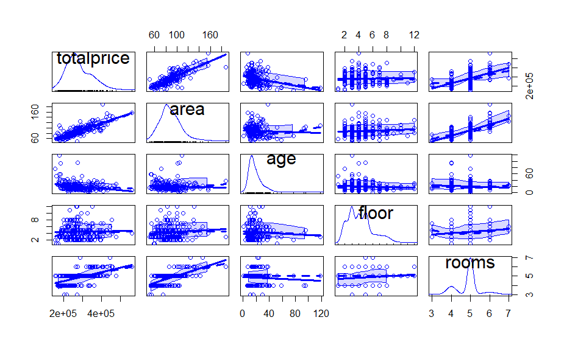

```r
VIT2005 <- within(VIT2005, {
  elevator <- as.numeric(as.character(elevator))
  storage  <- as.numeric(storage)
  toilets  <- as.numeric(toilets)
})
# e.g. matrix can be produced with
scatterplotMatrix( ~ totalprice + area + age + floor + rooms, data = VIT2005)
```

[output not shown]

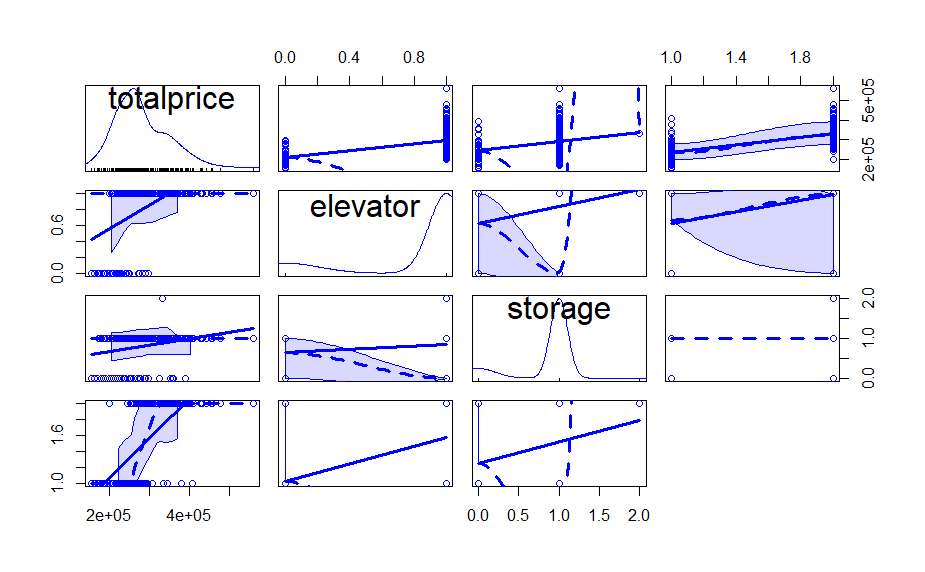

```r
scatterplotMatrix( ~ totalprice + elevator + storage + toilets, data = VIT2005 )
```

3. **Total of (55 pts)** **Quiz-Project 3** Pr.3 to 8, 10 pts for each correctly removed variable, 5 pts to find the correlation.

Compute the correlation between `totalprice` and all of the other numerical variables. List the **three** variables in order along with their correlation coefficients that have the highest correlation with totalprice.

#### **Model (A)**: Use backward elimination to develop a model that predicts totalprice using the data frame `VIT2005`. Use a “P-value-to remove” of `5`%. Store the final model in the object `modelA`.

**(5 pts)** **Quiz-Project 3 Pr.3**

The correlation coefficients are:

```r
NUM <- c("area", "age", "floor", "rooms", "toilets", "garage", "elevator", "storage")

# Make sure these are numeric (important for cor and some plotting functions)
VIT2005[NUM] <- lapply(VIT2005[NUM], function(x) as.numeric(as.character(x)))

COR <- cor(VIT2005[, "totalprice"], VIT2005[, NUM], use = "complete.obs")
COR
```

```
          area        age      floor    rooms   toilets    garage  elevator
[1,] 0.8092125 -0.2724497 0.02921993 0.525627 0.6875706 0.5237425 0.5109393
       storage
[1,] 0.2673579
```

**Observation:** The highest three correlations with `totalprice` occur with `area` (0.8092), `toilets` (0.6876), and `rooms`(0.5256).

**Model (A)** The functions `drop1()` and `update()` are used to create a model using backward elimination.

**Hint:** `drop1(model_.be_name, test = "F")` test for significance of all individual predictors given all others are already in the model.

```r
# use a model where totalprice is regressed on all other variables
model.be <- lm(totalprice ~ ., data = VIT2005)

#
drop1(model.be, test = "F")
```

```
Single term deletions

Model:
totalprice ~ area + zone + category + age + floor + rooms + out +
    conservation + toilets + garage + elevator + streetcategory +
    heating + storage
               Df  Sum of Sq        RSS    AIC F value    Pr(>F)
<none>                       8.5891e+10 4412.6
area            1 4.4519e+10 1.3041e+11 4501.7 87.5972 < 2.2e-16 ***
zone           22 1.1171e+11 1.9760e+11 4550.3  9.9910 < 2.2e-16 ***
category        6 9.5199e+09 9.5411e+10 4423.5  3.1219  0.006303 **
age             1 3.7563e+06 8.5895e+10 4410.6  0.0074  0.931591
floor           1 3.8440e+07 8.5929e+10 4410.7  0.0756  0.783639
rooms           1 1.0656e+09 8.6956e+10 4413.3  2.0967  0.149472
out             3 3.8946e+09 8.9785e+10 4416.3  2.5544  0.057135 .
conservation    3 1.0031e+09 8.6894e+10 4409.2  0.6579  0.579069
toilets         1 4.7971e+09 9.0688e+10 4422.5  9.4389  0.002477 **
garage          1 1.4771e+10 1.0066e+11 4445.2 29.0627 2.328e-07 ***
elevator        1 5.4265e+09 9.1317e+10 4424.0 10.6772  0.001314 **
streetcategory  3 3.5550e+09 8.9446e+10 4415.5  2.3316  0.076019 .
heating         3 4.3202e+09 9.0211e+10 4417.3  2.8335  0.039877 *
storage         1 1.6433e+09 8.7534e+10 4414.8  3.2334  0.073937 .
---
Signif. codes:  0 ‘***’ 0.001 ‘**’ 0.01 ‘*’ 0.05 ‘.’ 0.1 ‘ ’ 1
```

**(10 pts)** (part c.1) **Quiz-Project 3 Pr.4**

Which one appears most **insignificant** (biggest `P-value`)? Drop it from the model.

E.g. If `age` is most insignificant, use the `update` function to update the model with the following code:

`model.be <- update(model.be, .~. - age)` - the first dot means we use the same response variable, the second all previously included predictors minus `age`. The again use `drop1` and so on, until all remaining variables are of significance `0.05` as specified in the directions of the problem

YOUR CODE HERE:

```r
model.be <- update(model.be, .~. - age)
drop1(model.be, test = "F")
```

```
Single term deletions

Model:
totalprice ~ area + zone + category + floor + rooms + out + conservation +
    toilets + garage + elevator + streetcategory + heating +
    storage
               Df  Sum of Sq        RSS    AIC F value    Pr(>F)
<none>                       8.5895e+10 4410.6
area            1 4.4894e+10 1.3079e+11 4500.3 88.8523 < 2.2e-16 ***
zone           22 1.1220e+11 1.9810e+11 4548.8 10.0942 < 2.2e-16 ***
category        6 9.6605e+09 9.5555e+10 4421.9  3.1866 0.0054598 **
floor           1 3.6864e+07 8.5931e+10 4408.7  0.0730 0.7874016
rooms           1 1.0655e+09 8.6960e+10 4411.3  2.1088 0.1482969
out             3 4.0439e+09 8.9938e+10 4414.7  2.6678 0.0493562 *
conservation    3 1.3497e+09 8.7244e+10 4408.0  0.8905 0.4473466
toilets         1 4.7993e+09 9.0694e+10 4420.5  9.4987 0.0023994 **
garage          1 1.4767e+10 1.0066e+11 4443.2 29.2260 2.153e-07 ***
elevator        1 5.6740e+09 9.1569e+10 4422.6 11.2298 0.0009919 ***
streetcategory  3 3.5550e+09 8.9450e+10 4413.5  2.3453 0.0746761 .
heating         3 4.3716e+09 9.0266e+10 4415.5  2.8840 0.0373395 *
storage         1 1.6950e+09 8.7590e+10 4412.9  3.3547 0.0687625 .
---
Signif. codes:  0 ‘***’ 0.001 ‘**’ 0.01 ‘*’ 0.05 ‘.’ 0.1 ‘ ’ 1
```

**(10 pts)** (part c.2) **Quiz-Project 3 Pr.5**

Which one is to be dropped next?

Answer: Floor

```r
model.be <- update(model.be, .~. - age - floor)
drop1(model.be, test = "F")
```

```
Single term deletions

Model:
totalprice ~ area + zone + category + rooms + out + conservation +
    toilets + garage + elevator + streetcategory + heating +
    storage
               Df  Sum of Sq        RSS    AIC F value    Pr(>F)
<none>                       8.5931e+10 4408.7
area            1 4.4857e+10 1.3079e+11 4498.3 89.2643 < 2.2e-16 ***
zone           22 1.1713e+11 2.0306e+11 4552.2 10.5949 < 2.2e-16 ***
category        6 9.8951e+09 9.5826e+10 4420.5  3.2818 0.0044204 **
rooms           1 1.0703e+09 8.7002e+10 4409.4  2.1299 0.1462887
out             3 4.0364e+09 8.9968e+10 4412.7  2.6774 0.0487312 *
conservation    3 1.3563e+09 8.7288e+10 4406.1  0.8997 0.4426615
toilets         1 4.8110e+09 9.0742e+10 4418.6  9.5738 0.0023062 **
garage          1 1.4733e+10 1.0066e+11 4441.2 29.3185 2.054e-07 ***
elevator        1 5.7376e+09 9.1669e+10 4420.8 11.4175 0.0009011 ***
streetcategory  3 3.5188e+09 8.9450e+10 4411.5  2.3341 0.0757310 .
heating         3 4.4146e+09 9.0346e+10 4413.6  2.9283 0.0352446 *
storage         1 1.6588e+09 8.7590e+10 4410.9  3.3010 0.0709881 .
---
Signif. codes:  0 ‘***’ 0.001 ‘**’ 0.01 ‘*’ 0.05 ‘.’ 0.1 ‘ ’ 1
```

```r
formula(model.be)
```

```
totalprice ~ area + zone + category + rooms + out + conservation +
    toilets + garage + elevator + streetcategory + heating +
    storage
```

```r
attr(terms(model.be), "term.labels")
```

```
 [1] "area"           "zone"           "category"       "rooms"
 [5] "out"            "conservation"   "toilets"        "garage"
 [9] "elevator"       "streetcategory" "heating"        "storage"
```

**(10 pts)** (part c.3) **Quiz-Project 3 Pr.6** Which one is to be dropped next?

```r
model.be <- update(model.be, .~. - age - rooms - floor)
drop1(model.be, test = "F")
```

```
Single term deletions

Model:
totalprice ~ area + zone + category + out + conservation + toilets +
    garage + elevator + streetcategory + heating + storage
               Df  Sum of Sq        RSS    AIC  F value    Pr(>F)
<none>                       8.7002e+10 4409.4
area            1 6.4225e+10 1.5123e+11 4527.9 126.9717 < 2.2e-16 ***
zone           22 1.1619e+11 2.0319e+11 4550.3  10.4411 < 2.2e-16 ***
category        6 9.3536e+09 9.6355e+10 4419.7   3.0820 0.0068459 **
out             3 4.2390e+09 9.1241e+10 4413.8   2.7935 0.0419357 *
conservation    3 1.3106e+09 8.8312e+10 4406.7   0.8637 0.4611507
toilets         1 5.1652e+09 9.2167e+10 4420.0  10.2114 0.0016608 **
garage          1 1.4915e+10 1.0192e+11 4441.9  29.4873 1.894e-07 ***
elevator        1 6.2632e+09 9.3265e+10 4422.6  12.3821 0.0005547 ***
streetcategory  3 3.3653e+09 9.0367e+10 4411.7   2.2177 0.0878453 .
heating         3 4.5547e+09 9.1556e+10 4414.5   3.0015 0.0320428 *
storage         1 1.4713e+09 8.8473e+10 4411.1   2.9087 0.0899089 .
---
Signif. codes:  0 ‘***’ 0.001 ‘**’ 0.01 ‘*’ 0.05 ‘.’ 0.1 ‘ ’ 1
```

**(10 pts)** (part c.4) **Quiz-Project 3 Pr.7** Which one is to be dropped next?

Answer: Conservation

```r
model.be <- update(model.be, .~. - age - rooms - floor - conservation)
drop1(model.be, test = "F")
```

```
Single term deletions

Model:
totalprice ~ area + zone + category + out + toilets + garage +
    elevator + streetcategory + heating + storage
               Df  Sum of Sq        RSS    AIC  F value    Pr(>F)
<none>                       8.8312e+10 4406.7
area            1 6.3300e+10 1.5161e+11 4522.5 125.4358 < 2.2e-16 ***
zone           22 1.1695e+11 2.0526e+11 4546.5  10.5341 < 2.2e-16 ***
category        6 1.2113e+10 1.0043e+11 4422.7   4.0004 0.0008860 ***
out             3 4.8644e+09 9.3177e+10 4412.4   3.2131 0.0243109 *
toilets         1 5.4584e+09 9.3771e+10 4417.8  10.8163 0.0012163 **
garage          1 1.5751e+10 1.0406e+11 4440.5  31.2116 8.718e-08 ***
elevator        1 6.3078e+09 9.4620e+10 4419.7  12.4996 0.0005209 ***
streetcategory  3 3.3915e+09 9.1704e+10 4408.9   2.2402 0.0852905 .
heating         3 4.1435e+09 9.2456e+10 4410.7   2.7369 0.0450560 *
storage         1 1.5008e+09 8.9813e+10 4408.4   2.9740 0.0863783 .
---
Signif. codes:  0 ‘***’ 0.001 ‘**’ 0.01 ‘*’ 0.05 ‘.’ 0.1 ‘ ’ 1
```

**(10 pts)** (part c.5) **Quiz-Project 3 Pr.8** Which one is to be dropped next?

Answer: Storage

```r
model.be <- update(model.be, .~. - age - rooms - floor - storage)
drop1(model.be, test = "F")
```

```
Single term deletions

Model:
totalprice ~ area + zone + category + out + toilets + garage +
    elevator + streetcategory + heating
               Df  Sum of Sq        RSS    AIC  F value    Pr(>F)
<none>                       8.9813e+10 4408.4
area            1 6.4458e+10 1.5427e+11 4524.3 126.3141 < 2.2e-16 ***
zone           22 1.1977e+11 2.0959e+11 4549.1  10.6688 < 2.2e-16 ***
category        6 1.1488e+10 1.0130e+11 4422.6   3.7521  0.001540 **
out             3 4.9656e+09 9.4779e+10 4414.1   3.2436  0.023353 *
toilets         1 5.6974e+09 9.5511e+10 4419.8  11.1647  0.001018 **
garage          1 1.6124e+10 1.0594e+11 4442.4  31.5962  7.32e-08 ***
elevator        1 6.8119e+09 9.6625e+10 4422.3  13.3488  0.000341 ***
streetcategory  3 4.5260e+09 9.4339e+10 4413.1   2.9564  0.033902 *
heating         3 4.2935e+09 9.4107e+10 4412.5   2.8046  0.041267 *
---
Signif. codes:  0 ‘***’ 0.001 ‘**’ 0.01 ‘*’ 0.05 ‘.’ 0.1 ‘ ’ 1
```

If all variable are significant create the object holding the optimal model as per the description of the problem using the code:

```r
formula(model.be)
```

```
totalprice ~ area + zone + category + out + toilets + garage +
    elevator + streetcategory + heating
```

```r
modelA <- lm(formula(model.be), data = VIT2005)

summary(modelA)
```

```
Call:
lm(formula = formula(model.be), data = VIT2005)

Residuals:
   Min     1Q Median     3Q    Max
-70628 -12820    835  12685  64757

Coefficients:
                 Estimate Std. Error t value Pr(>|t|)
(Intercept)       89431.2    24819.7   3.603 0.000409 ***
area               1424.6      126.8  11.239  < 2e-16 ***
zoneZ21           93167.5    13333.7   6.987 5.56e-11 ***
zoneZ31           82075.2    13917.9   5.897 1.85e-08 ***
zoneZ32           41292.1    12324.5   3.350 0.000987 ***
zoneZ34           17004.4    15462.7   1.100 0.272962
zoneZ35           59666.4    14856.1   4.016 8.74e-05 ***
zoneZ36           39871.6    12638.4   3.155 0.001889 **
zoneZ37           75492.2    12856.9   5.872 2.10e-08 ***
zoneZ38           23990.9    15762.5   1.522 0.129797
zoneZ41           54662.5    12150.8   4.499 1.24e-05 ***
zoneZ42           83760.3    15632.3   5.358 2.61e-07 ***
zoneZ43           34608.6    15827.9   2.187 0.030094 *
zoneZ44           21439.4    15182.2   1.412 0.159674
zoneZ45           16063.5    12663.1   1.269 0.206283
zoneZ46            9283.4    13415.1   0.692 0.489844
zoneZ47           -9269.5    14160.7  -0.655 0.513586
zoneZ48           37692.4    13904.6   2.711 0.007377 **
zoneZ49           31076.9    14866.7   2.090 0.038021 *
zoneZ52            4999.8    12848.9   0.389 0.697656
zoneZ53           20919.2    12984.5   1.611 0.108951
zoneZ56           22766.0    14653.2   1.554 0.122062
zoneZ61           17299.4    12102.2   1.429 0.154651
zoneZ62           14561.6    12169.3   1.197 0.233079
category2B        -1835.8    14725.9  -0.125 0.900930
category3A       -21887.0    14324.6  -1.528 0.128324
category3B       -26054.0    14694.9  -1.773 0.077960 .
category4A       -34968.7    15268.9  -2.290 0.023197 *
category4B       -42480.3    15970.7  -2.660 0.008539 **
category5A       -73192.8    25008.9  -2.927 0.003878 **
outE25            40261.1    14578.1   2.762 0.006359 **
outE50            -3726.0     4003.0  -0.931 0.353233
outE75             5444.5    10457.8   0.521 0.603285
toilets           18985.4     5681.9   3.341 0.001018 **
garage            25834.4     4596.0   5.621 7.32e-08 ***
elevator          21164.4     5792.8   3.654 0.000341 ***
streetcategoryS3  14006.1     5699.3   2.457 0.014960 *
streetcategoryS4   9242.9     6274.8   1.473 0.142534
streetcategoryS5  -6662.7    10455.6  -0.637 0.524800
heating3A         -3850.8    11756.3  -0.328 0.743642
heating3B          4831.8    15017.0   0.322 0.748019
heating4A          9488.2    12390.5   0.766 0.444841
---
Signif. codes:  0 ‘***’ 0.001 ‘**’ 0.01 ‘*’ 0.05 ‘.’ 0.1 ‘ ’ 1

Residual standard error: 22590 on 176 degrees of freedom
Multiple R-squared:  0.9138,    Adjusted R-squared:  0.8937
F-statistic: 45.51 on 41 and 176 DF,  p-value: < 2.2e-16
```

**Note to self:** From the output, median residual is 835 (close to 0), which is good (no big systematic over/under prediction at the median). Residual spread is roughly Q1 = -12,820 / Q3 = 12,685 so a typical error is on the order of ~ plus/minus13k euros. Extremes range from about -70,628 to +64,757 suggesting some apartments are harder to predict.

**Question 1: (5 pts)** **Quiz-Project 3 Pr.9** Which variables are left in the model, list them?

1. **(5 pts)** **Quiz-Project 3 Pr.10**

Compute $CV_n$, the leave-one-out cross validation error, for `modelA`. Set the seed to `5` and compute $CV_5$, the **five-fold** cross validation error, for `modelA`. The cross validation error for a generalized linear model can be computed using the `cv.glm()` from the `boot` package. Using the function `glm()` without passing a family argument is the same as using the function `lm()`. `R Code 12.3` provides a template of how to use the `cv.glm()` function. Note that $CV_n$ is returned with `cv.error$delta[1]`. To compute $CV_5$, pass the value `5` to the argument `K` inside the `cv.glm()` function.

```r
## CV_n : Leave-one-out cross validation error (LOOCV)
glmA <- glm(formula(modelA), data = VIT2005)   # glm() w/ no family = same as lm()
cv.error <- cv.glm(VIT2005, glmA)             # default is LOOCV

CV_n <- cv.error$delta[1]
CV_n
```

```
[1] 647026246
```

```r
## CV_5 : 5-fold cross validation error
set.seed(5)
cv.error5 <- cv.glm(VIT2005, glmA, K = 5)

CV_5 <- cv.error5$delta[1]
CV_5
```

```
[1] 652546038
```

2. **(5 pts)** **Quiz-Project 3 Pr.11**

Compute $R^2$, $R^2_a$, the `AIC`, and the `BIC` for **Model (A)**. What is the proportion of total variability explained by **Model (A)**?

**Your Solution:**

```r
modelAg <- glm(formula(model.be), data = VIT2005)

# # For cv.glm - the default is to set K equal to the number of observations in data which gives the usual leave-one-out cross-validation.
#
set.seed(5) # use for replication purposes
cv.errorN <- cv.glm(data = VIT2005, glmfit =  modelAg)

CVNa <- cv.errorN$delta[1]
CVNa
```

```
[1] 647026246
```

```r
modelAg <- glm(formula(model.be), data = VIT2005)

# UNCOMMENT the code below and run it

 set.seed(5) # use for replication purposes
 cv.error5 <- cv.glm(data = VIT2005, glmfit = modelAg, K = 5)
 CV5a <- cv.error5$delta[1]
 CV5a
```

```
[1] 652546038
```

2. Since this problem and a few more will request many goodness of fit statistics, a function called `mgof()` is written to compute the requested values. **Use it as shown below**.

```r
mgof <- function(model = model, data = DF, ...){
  R2a <- summary(model)$adj.r.squared
  R2 <- summary(model)$r.squared
  aic <- AIC(model)
  bic <- AIC(model, k = log(nrow(data)))
  se <- summary(model)$sigma
  form <- formula(model)
  ANS <- c(R2 = R2, R2.adj = R2a, AIC = aic, BIC = bic, SE = se)
  ANS
}

MGOF <- mgof(model = modelA, data = VIT2005)
MGOF
```

```
          R2       R2.adj          AIC          BIC           SE
9.138147e-01 8.937375e-01 5.029015e+03 5.174548e+03 2.258987e+04
```

Observation: The total proportion of variability ($R^2$) explained by modelA is `0.9138`.

4. **(10 pts)** **Quiz-Project 3 Pr.12**

Explore the residuals of the Models (A) using the function `residualPlot()` or `residualPlots()` from the package `car`. Comment on the results. (**Diagnostics: Checking the model assumptions**)

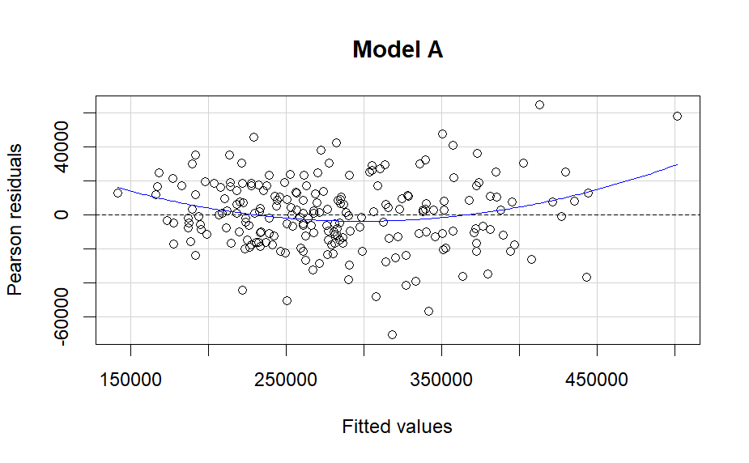

```r
# uncomment to run the residual plot for the modelA
 residualPlot(modelA, main = "Model A")
```

**(d) Question 2:** Is there curvature of the residuals on the above plot?

Observation: The residuals versus the fitted values for Model (A) have a definite curvature indicating the model is not quite adequate.

There appears to be **mild curvature** in the residual plot (the smoother is not horizontal), suggesting a possible violation of the linearity assumption.

**Extra Credit** (10 pts) **Quiz-Project 3 Pr.13**

**(e)** Use the function `boxCox()` from car to find a suitable transformation for totalprice. Build Model (E) Use backward elimination to develop a model that predicts `log(totalprice)` using the data frame `VIT2005`. Use a “P-value-to remove” of 5%. Store the final model in the object `modelE`.

For details on `boxCox()` see page 856 in text

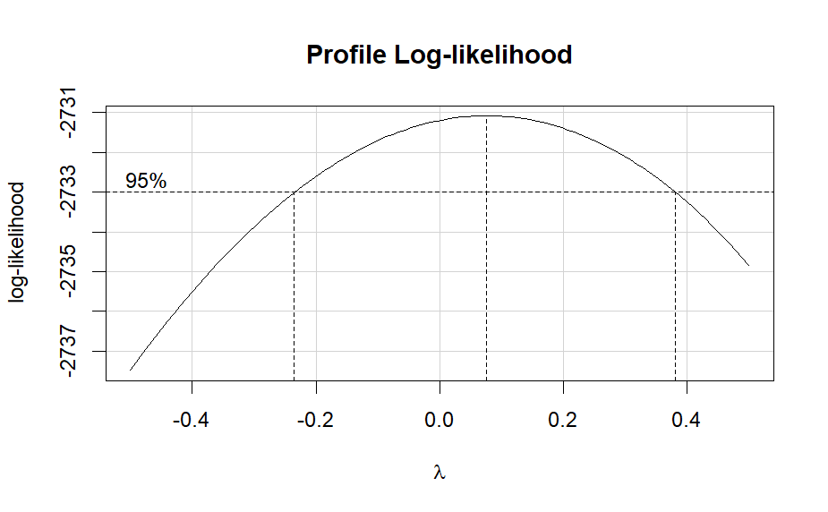

```r
boxCox(modelA, lambda = seq(-0.5, 0.5, length = 200))
```

#### Observation:

A `log` transformation is suggested for the response `totalprice` in **Model (A)**.

**Extra Credit** (20 pts) **Quiz-Project 3 Pr.14** - 4 pts for excluding the correct variable at each step.

#### **Model (E)**:

Use backward elimination to develop a model that predicts `log(totalprice)` using the data frame `VIT2005`. Use a “P-value-to remove” of `5`%. Store the final model in the object `modelE`.

**Model (E)** The functions `drop1()` and `update()` are used to create a model using backward elimination. (as shown at the beginning)

```r
# transform the response variable using natural log transformation

VITNEW <- VIT2005 %>% mutate(logtotalprice = log(totalprice))

# build the fitted full model
model.be <- lm(logtotalprice ~ ., data = VITNEW[ ,-1]) # exclude the totalprice variable since it is no longer response variable
drop1(model.be, test = "F")
```

```
Single term deletions

Model:
logtotalprice ~ area + zone + category + age + floor + rooms +
    out + conservation + toilets + garage + elevator + streetcategory +
    heating + storage
               Df Sum of Sq     RSS      AIC F value    Pr(>F)
<none>                      0.97895 -1080.46
area            1   0.45808 1.43703  -998.78 79.0794 8.788e-16 ***
zone           22   1.25852 2.23747  -944.25  9.8756 < 2.2e-16 ***
category        6   0.10125 1.08020 -1071.00  2.9132  0.009938 **
age             1   0.00061 0.97956 -1082.32  0.1045  0.746909
floor           1   0.00185 0.98080 -1082.05  0.3191  0.572909
rooms           1   0.00422 0.98317 -1081.52  0.7279  0.394766
out             3   0.06721 1.04616 -1071.98  3.8675  0.010426 *
conservation    3   0.01134 0.99029 -1083.95  0.6523  0.582546
toilets         1   0.08460 1.06356 -1064.39 14.6057  0.000186 ***
garage          1   0.14304 1.12199 -1052.73 24.6935 1.636e-06 ***
elevator        1   0.14529 1.12424 -1052.29 25.0826 1.373e-06 ***
streetcategory  3   0.03040 1.00935 -1079.79  1.7492  0.158880
heating         3   0.04007 1.01902 -1077.71  2.3060  0.078550 .
storage         1   0.03280 1.01175 -1075.27  5.6625  0.018445 *
---
Signif. codes:  0 ‘***’ 0.001 ‘**’ 0.01 ‘*’ 0.05 ‘.’ 0.1 ‘ ’ 1
```

and so on.

```r
VITNEW <- VIT2005 %>% mutate(logtotalprice = log(totalprice))

# build the fitted full model
model.be <- lm(logtotalprice ~ ., data = VITNEW[ ,-1]) # exclude the totalprice variable since it is no longer response variable

model.be <- update(model.be, .~. - age - floor - rooms - conservation - streetcategory)

drop1(model.be, test = "F")
```

```
Single term deletions

Model:
logtotalprice ~ area + zone + category + out + toilets + garage +
    elevator + heating + storage
         Df Sum of Sq    RSS      AIC  F value    Pr(>F)
<none>                1.0273 -1087.95
area      1   0.60883 1.6361  -988.50 105.4941 < 2.2e-16 ***
zone     22   1.32896 2.3562  -950.98  10.4671 < 2.2e-16 ***
category  6   0.13418 1.1615 -1073.19   3.8749  0.001164 **
out       3   0.07692 1.1042 -1078.21   4.4426  0.004885 **
toilets   1   0.09796 1.1252 -1070.10  16.9737 5.799e-05 ***
garage    1   0.15375 1.1810 -1059.55  26.6413 6.501e-07 ***
elevator  1   0.15048 1.1778 -1060.15  26.0751 8.391e-07 ***
heating   3   0.04847 1.0757 -1083.90   2.7994  0.041510 *
storage   1   0.04202 1.0693 -1081.21   7.2813  0.007638 **
---
Signif. codes:  0 ‘***’ 0.001 ‘**’ 0.01 ‘*’ 0.05 ‘.’ 0.1 ‘ ’ 1
```

```r
# backwards elimination
```